# CP_04_VentasApple

German de los Mozos

16/11/2020

### Introducción

Primero observamos la evolución de las ventas durante el periodo estimado. Podemos ver que existe una tendencia positiva, con lo cual la media no es constante, y tampoco lo es su varianza, por lo que los datos no serían estacionarios.

Se puede apreciar también cierta estacionalidad en los datos.

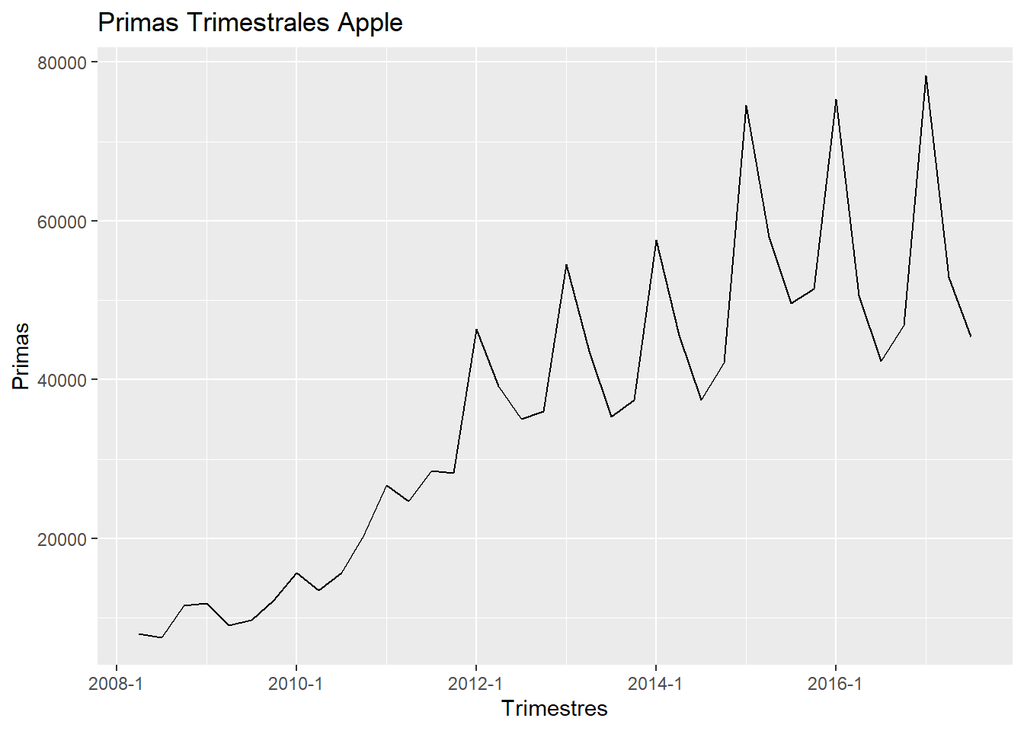

```r
# Graficamos la serie

autoplot(zVentas) + ggtitle("Primas Trimestrales Apple") + xlab("Trimestres") + ylab("Primas")
```

### Modelo ETS

Primero vamos a ajustar el modelo ETS. Para ello, se omiten los tres trimestres de 2017, para poder hacer luego una comparación del modelo de predicción para ese año, con los datos reales.

De manera muy sencilla en R, obtenemos el modelo predcitivo ETS para las ventas de Apple, que tiene el siguiente resumen. Con él podemos ver las predicciones, junto con unos intervalos de confianza a dos niveles de significación diferentes, para los años 2017 y 2018

```r
# Seleccionar modelo ETS automaticamente

etsfit <- ets(oVentas)

# Modelo forecast

fventas.ets = forecast(etsfit)

# Resultados

summary(fventas.ets)
```

```
##
## Forecast method: ETS(M,A,M)
##
## Model Information:
## ETS(M,A,M)
##
## Call:
##  ets(y = oVentas)
##
##   Smoothing parameters:
##     alpha = 0.493
##     beta  = 0.493
##     gamma = 0.507
##
##   Initial states:
##     l = 7125.3462
##     b = 1485.7975
##     s = 1.1511 1.1163 0.8322 0.9004
##
##   sigma:  0.1222
##
##      AIC     AICc      BIC
## 703.9538 711.1538 717.9519
##
## Error measures:
##                   ME     RMSE      MAE       MPE     MAPE      MASE      ACF1
## Training set -41.934 4120.155 2883.262 -0.297759 8.677434 0.4160202 0.1438481
##
## Forecasts:
##         Point Forecast     Lo 80     Hi 80      Lo 95     Hi 95
## 2017 Q1       69439.83 58568.387  80311.27  52813.394  86066.26
## 2017 Q2       53347.98 41773.016  64922.95  35645.598  71050.37
## 2017 Q3       48972.04 33884.613  64059.47  25897.811  72046.27
## 2017 Q4       54176.09 31475.035  76877.14  19457.824  88894.35
## 2018 Q1       80540.07 32680.293 128399.85   7344.857 153735.28
## 2018 Q2       61619.03 17211.212 106026.85  -6296.866 129534.93
## 2018 Q3       56344.41  7869.773 104819.05 -17791.151 130479.97
## 2018 Q4       62103.80  -718.363 124925.97 -33974.410 158182.02
```

Podemos ver estos resultados en una gráfica, donde comparamos con los datos reales. Vemos que la predicción para los tres primeros trimestres de 2017 se acerca bastante al dato real, incluso, acierta completamente en el segundo trimestre.

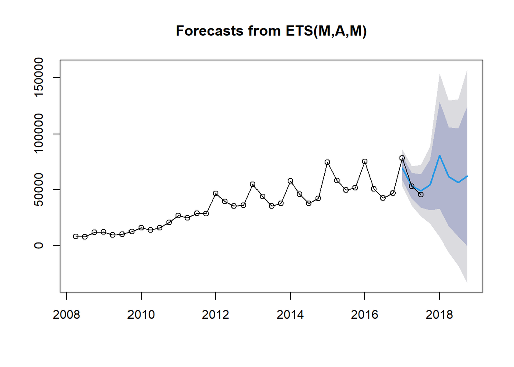

```r
# Dibujamos
plot(fventas.ets)
lines(window(zVentas),type="o")
```

Aquí podemos ver numéricamente la comparación entre los datos reales y la predicción, para los datos de 2017

```r
#Contrastamos los datos reales con los datos predichos

rows <- list("Q1 2017", "Q2 2017", "Q3 2017")
columns <- list("Prediccion", "Real")
ma <- list(rows, columns)

matrix(c(fventas.ets$mean[1:cOmit],zVentas[(nObs-cOmit+1):nObs]), ncol=2, dimnames = ma)
```

```
##         Prediccion  Real
## Q1 2017   69439.83 78351
## Q2 2017   53347.98 52896
## Q3 2017   48972.04 45408
```

### Modelo ARIMA

A continuación, vamos a estimar el modelo ARIMA para las ventas de Apple. Utilizando la división de muestra anteriormente realizada, obtenemos los siguientes resultados.

```r
# Utilizamos la separacion de la muestra realizada para el modelo ETS

fitARIMA = auto.arima(oVentas,lambda = 0)
summary(fitARIMA)
```

```
## Series: oVentas
## ARIMA(0,1,0)(0,1,0)[4]
## Box Cox transformation: lambda= 0
##
## sigma^2 estimated as 0.01472:  log likelihood=20.72
## AIC=-39.45   AICc=-39.3   BIC=-38.04
##
## Training set error measures:
##                     ME     RMSE      MAE       MPE     MAPE      MASE      ACF1
## Training set -764.5058 4786.405 3054.054 -1.321616 8.284962 0.4406634 0.1269135
```

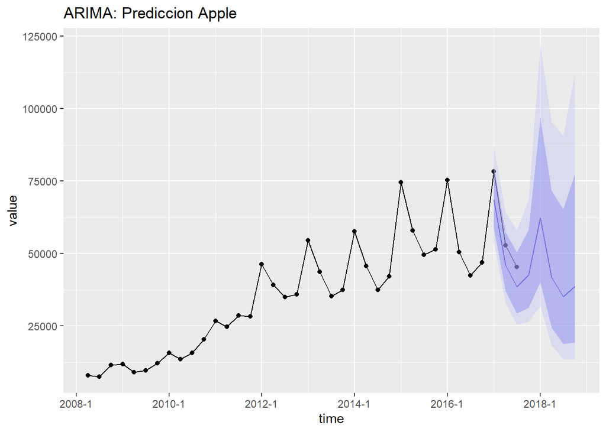

```r
# Modelo forecast ARIMA
fventas.ARIMA = forecast(fitARIMA)


# Dibujamos los datos reales junto a la prediccion

df_new <- data.frame(value = as.vector(zVentas),
                     time = time(zVentas))

ggplot(df_new) + geom_point(aes(x = time,y = value)) + geom_line(aes(x = time,y = value)) +  geom_forecast(fventas.ARIMA, alpha = 0.4) + ggtitle("ARIMA: Prediccion Apple")
```

Lo comprobamos numéricamente:

```r
# Contrastamos los datos reales con los datos predichos

matrix(c(fventas.ARIMA$mean[1:cOmit],zVentas[(nObs-cOmit+1):nObs]),ncol=2, dimnames = ma)
```

```
##         Prediccion  Real
## Q1 2017   68524.50 78351
## Q2 2017   45993.21 52896
## Q3 2017   38534.34 45408
```

### Comprobación ambos modelos

El último paso de este análisis es comprobar la precisión de los dos modelos estimados, para decidir cuál de ellos predice mejor.

```r
# Comprobamos la precisión de ambos modelos
ETSprecision <- forecast:::testaccuracy(fventas.ets$mean,window(zVentas,start=2017),test = NULL, d = NULL, D = NULL)

ARIMAprecision <- forecast:::testaccuracy(fventas.ARIMA$mean,window(zVentas,start=2017),test = NULL, d = NULL, D = NULL)

# Lo vemos conjuntamente
cbind(data.frame(ETSprecision), data.frame(ARIMAprecision))
```

```
##      ETSprecision ARIMAprecision
## ME   1631.7148548     7867.64999
## RMSE 5547.2411636     7988.65527
## MAE  4309.0658524     7867.64999
## MPE     0.8899969       13.57631
## MAPE    6.6922684       13.57631
```

El modelo ETS presenta valores más pequeños de RMSE y MAPE, por lo que elegiremos este modelo ETS como el mejor predictor.